# Part II - What Drives the Cost of Borrowing?

## Investigation Overview

> My goal is to analyze the factors influencing loan interest rates (BorrowerAPR) in the Prosper dataset.

## Dataset Overview and Executive Summary

This dataset is the Prosper Loan Data dataset. It contains 113,937 loans with 81 variables on each loan, including loan amount, borrower rate (or interest rate), current loan status, borrower income, and many others. The listings span from late 2005 to early 2014.

```python
# import all packages and set plots to be embedded inline
import numpy as np
import pandas as pd
import matplotlib.pyplot as plt
import seaborn as sns
import matplotlib.ticker as mtick

# suppress warnings from final output
import warnings
warnings.simplefilter("ignore")
```

```python
# load in the dataset into a pandas dataframe
df = pd.read_csv("prosperLoanData.csv")
```

Setup: drop missing values and define ordinal order

```python
df = df.dropna(subset = ['BorrowerAPR'])
order_rankings = ['AA', 'A', 'B', 'C', 'D', 'E', 'HR']
```

## Distribution of Borrower APR and the 35.8% Rate Spike

> BorrowerAPR is the total annual cost of the loan to the borrower. It has a distribution centered around 15%-20% with an unusual, massive spike around 35.8%.

```python
# 1% bin width
bins = np.arange(0, df['BorrowerAPR'].max() + 0.01, 0.01)
```

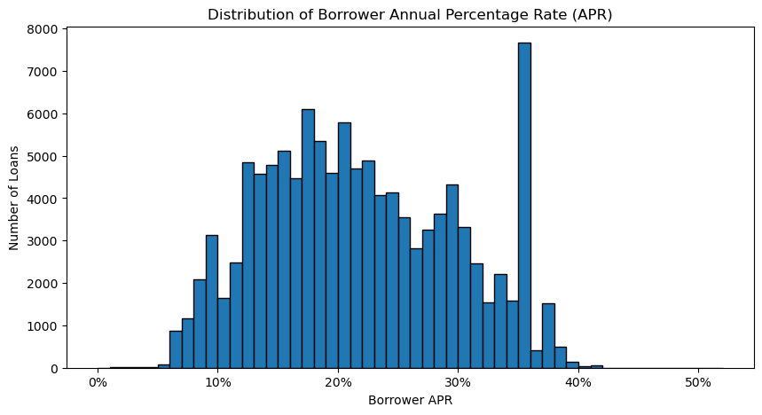

```python
fig, ax = plt.subplots(figsize=(10,5))
plt.hist(data=df, x='BorrowerAPR', bins=bins, edgecolor='black', color=sns.color_palette()[0])

ax.xaxis.set_major_formatter(mtick.PercentFormatter(xmax=1.0))

plt.xlabel('Borrower APR')
plt.ylabel('Number of Loans')
plt.title('Distribution of Borrower Annual Percentage Rate (APR)')


plt.show()
```

BorrowerAPR is the total annual cost of the loan to the borrower. It has a distribution centered around 15-20% with an unusual, massive spike around 35%. In the next two visualizations, we will see which borrower and loan characteristics explain this wide spread and what drives the 35% spike.

## Borrower APR Across Credit Rating Tiers

> This plot will display a comparison of BorrowerAPR across all 7 ordered credit tiers in Prosper (AA through HR). These credit tiers represent credit risk, and the higher the rating (HR = High Risk) the higher the risk. We see as credit ratings risk increase the median interest rate climbs up. In the highest risk category, HR, the data is heavily compressed against the platform's interest rate cap of 35%, revealing where the massive spike from slide 1 came from.

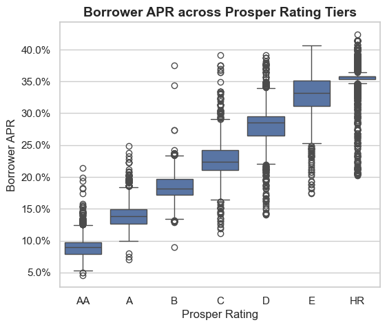

```python
sns.set_theme(style="whitegrid")

fig, ax = plt.subplots(figsize=(6,5))
sns.boxplot(data=df, x="ProsperRating (Alpha)", y="BorrowerAPR", order=order_rankings, color=sns.color_palette()[0])

ax.yaxis.set_major_formatter(mtick.PercentFormatter(xmax=1.0))

plt.title('Borrower APR across Prosper Rating Tiers', fontsize=14, fontweight='bold')
plt.xlabel('Prosper Rating')
plt.ylabel('Borrower APR')
plt.show()
```

As evidenced above, the medians of the APRs of each credit rating increases as does rank. At the highest risk rating HR, the majority of loans are concentrated in around 35%, though there are outliers.

## Does Borrowing More Money Get You a Lower APR?

```python
df_sample = df.sample(n=10000, random_state=42)
```

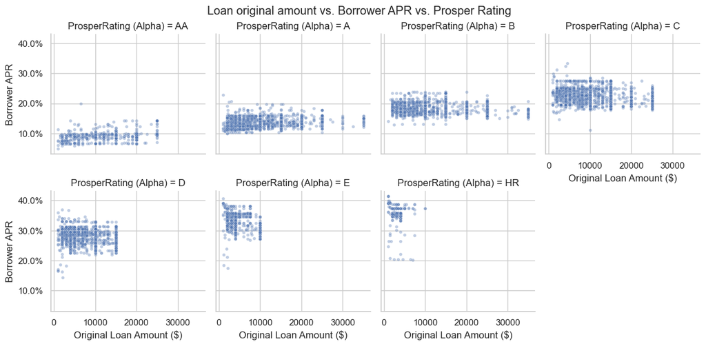

```python
g = sns.FacetGrid(df_sample, col='ProsperRating (Alpha)', col_wrap=4, col_order=order_rankings)
g.map(sns.scatterplot, 'LoanOriginalAmount', 'BorrowerAPR', alpha=0.35, s=15)

# Apply percent formatter ro each ax in the grid
for ax in g.axes.flat:
    ax.yaxis.set_major_formatter(mtick.PercentFormatter(xmax=1.0))

g.set_axis_labels("Original Loan Amount ($)", "Borrower APR")
g.fig.subplots_adjust(top=0.9)
g.fig.suptitle("Loan original amount vs. Borrower APR vs. Prosper Rating")
plt.show()
```

As we can see above, the lowest risk rating AA has the loans concentrated around the lower APR ratings. As we go up in risk rank, the concentration gets smaller and moves up, corresponding to smaller loans with higher APR.